# Linear regression

Rita.U.Kayitana

2026-11-11

INTRODUCTION

Multiple linear regression is a statistical method used to model the relationship between a single continuous dependent variable (Y) and two or more independent predictor variables (X), allowing us to estimate how changes in predictors impact the outcome while holding other variables constant. Beyond looking at coefficients, you must always verify Ordinary Least Squares (OLS) assumptions such as linearity, homoscedasticity, and the absence of severe multicollinearity among predictors because violating these assumptions can bias standard errors and invalidate hypothesis tests.

Dependent Variable (Y): mpg (Miles per US Gallon) Fuel economy. Independent Variables (X_1, X_2, X_3):Engine power(hp), Vehicle weight(wt) and Acceleration speed(qsec).

Step 1: Load and inspect the dataset

```r
data(mtcars)
head(mtcars)
```

```
##                    mpg cyl disp  hp drat    wt  qsec vs am gear carb
## Mazda RX4         21.0   6  160 110 3.90 2.620 16.46  0  1    4    4
## Mazda RX4 Wag     21.0   6  160 110 3.90 2.875 17.02  0  1    4    4
## Datsun 710        22.8   4  108  93 3.85 2.320 18.61  1  1    4    1
## Hornet 4 Drive    21.4   6  258 110 3.08 3.215 19.44  1  0    3    1
## Hornet Sportabout 18.7   8  360 175 3.15 3.440 17.02  0  0    3    2
## Valiant           18.1   6  225 105 2.76 3.460 20.22  1  0    3    1
```

```r
str(mtcars)
```

```
## 'data.frame':    32 obs. of  11 variables:
##  $ mpg : num  21 21 22.8 21.4 18.7 18.1 14.3 24.4 22.8 19.2 ...
##  $ cyl : num  6 6 4 6 8 6 8 4 4 6 ...
##  $ disp: num  160 160 108 258 360 ...
##  $ hp  : num  110 110 93 110 175 105 245 62 95 123 ...
##  $ drat: num  3.9 3.9 3.85 3.08 3.15 2.76 3.21 3.69 3.92 3.92 ...
##  $ wt  : num  2.62 2.88 2.32 3.21 3.44 ...
##  $ qsec: num  16.5 17 18.6 19.4 17 ...
##  $ vs  : num  0 0 1 1 0 1 0 1 1 1 ...
##  $ am  : num  1 1 1 0 0 0 0 0 0 0 ...
##  $ gear: num  4 4 4 3 3 3 3 4 4 4 ...
##  $ carb: num  4 4 1 1 2 1 4 2 2 4 ...
```

Count missing values across columns

```r
colSums(is.na(mtcars))
```

```
##  mpg  cyl disp   hp drat   wt qsec   vs   am gear carb
##    0    0    0    0    0    0    0    0    0    0    0
```

```r
sum(is.na(mtcars))                               #there are no missing values
```

```
## [1] 0
```

Step 2: Fit the Multiple Linear Regression Model

Model Equation: mpg = beta_0 + beta_1*(hp) + beta_2*(wt) + beta_3*(qsec) + epsilon

```r
model <- lm(mpg ~ hp + wt + qsec, data = mtcars)  # Fits OLS regression predicting mpg using hp, wt, and qsec
```

Step 3: Summary output of the model

```r
model_summary <- summary(model)    # Computes and stores the full statistical summary table of the model
print(model_summary)               # Prints the summary table showing coefficients, t-values, p-values, and R-squared
```

```
##
## Call:
## lm(formula = mpg ~ hp + wt + qsec, data = mtcars)
##
## Residuals:
##     Min      1Q  Median      3Q     Max
## -3.8591 -1.6418 -0.4636  1.1940  5.6092
##
## Coefficients:
##             Estimate Std. Error t value Pr(>|t|)
## (Intercept) 27.61053    8.41993   3.279  0.00278 **
## hp          -0.01782    0.01498  -1.190  0.24418
## wt          -4.35880    0.75270  -5.791 3.22e-06 ***
## qsec         0.51083    0.43922   1.163  0.25463
## ---
## Signif. codes:  0 '***' 0.001 '**' 0.01 '*' 0.05 '.' 0.1 ' ' 1
##
## Residual standard error: 2.578 on 28 degrees of freedom
## Multiple R-squared:  0.8348, Adjusted R-squared:  0.8171
## F-statistic: 47.15 on 3 and 28 DF,  p-value: 4.506e-11
```

```r
# Extract coefficient table
coef_table <- as.data.frame(model_summary$coefficients)
colnames(coef_table) <- c("Estimate", "Std. Error", "t value", "p value")
knitr::kable(round(coef_table, 4), caption = "Multiple Regression Coefficients")
```

Multiple Regression Coefficients

|  | Estimate | Std. Error | t value | p value |
| --- | --- | --- | --- | --- |
| (Intercept) | 27.6105 | 8.4199 | 3.2792 | 0.0028 |
| hp | -0.0178 | 0.0150 | -1.1896 | 0.2442 |
| wt | -4.3588 | 0.7527 | -5.7909 | 0.0000 |
| qsec | 0.5108 | 0.4392 | 1.1630 | 0.2546 |

Intercept = 27.61 predicted mpg when all predictors equal zero. Horsepower (hp = -0.018$): Each 1-unit increase in horsepower decreases fuel economy by 0.018 mpg. Weight (wt = -4.358): Each 1,000 lb increase in vehicle weight decreases fuel economy by 4.358 mpg. qsec = 0.511: Each 1-second increase in acceleration time increases fuel economy by 0.511 mpg

Step 4: Extract Key Metrics for Interpretation

```r
# Step 4: Extract Key Metrics for Interpretation
summary(model)$r.squared       # Prints the R-squared value
```

```
## [1] 0.8347678
```

```r
summary(model)$adj.r.squared   # Prints the Adjusted R-squared value
```

```
## [1] 0.8170643
```

R^2 = 0.835:Measures goodness of fit. It indicates that 83.5% of the total variance in fuel economy (mpg) is jointly explained by horsepower, weight, and quarter-mile time.

$H_0: \beta_1 = \beta_2 = \beta_3 = 0$ null hypothesis

$H_1: \text{At least one } \beta_i \neq 0$ alternative hypothesis

```r
# Extract F-statistic and calculate overall model p-value
f_stat <- model_summary$fstatistic
f_p_val <- pf(f_stat[1], f_stat[2], f_stat[3], lower.tail = FALSE)

cat("F-statistic:", round(f_stat[1], 4), "with p-value:", format.pval(f_p_val))
```

```
## F-statistic: 47.1528 with p-value: 4.5064e-11
```

Step 5: Residual Diagnostics Plots

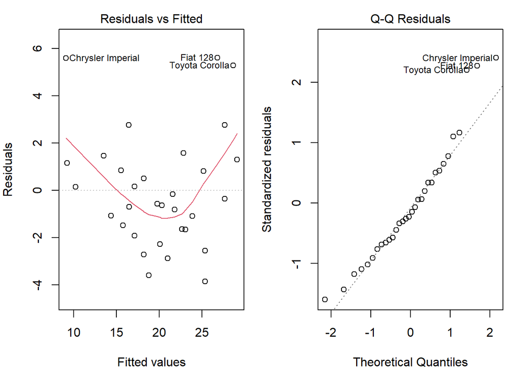

```r
# Set up a 1x2 grid layout for the most critical diagnostic plots
par(mfrow = c(1, 2), mar = c(4, 4, 2, 1))

# 1. Residuals vs. Fitted (checks linearity and constant error variance)
plot(model, which = 1)

# 2. Normal Q-Q Plot (checks if residuals are normally distributed)
plot(model, which = 2)
```

```r
# Reset the plotting layout and margins back to normal
par(mfrow = c(1, 1), mar = c(5, 4, 4, 2) + 0.1)
```

CONCLUSION Using the built-in mtcars dataset, we successfully fitted a multiple linear regression model explaining vehicle fuel efficiency using horsepower, weight, and acceleration time. The model achieved an $R^2$ of 0.835, demonstrating explanatory power, with vehicle weight standing out as the primary statistically significant determinant of fuel consumption.